# sklearn.utils.shuffle

**sklearn.utils.shuffle(*arrays, *random_state=None*, *n_samples=None*)[[source]](https://github.com/scikit-learn/scikit-learn/blob/f3f51f9b6/sklearn/utils/__init__.py#L585)**

Shuffle arrays or sparse matrices in a consistent way.

This is a convenience alias to `resample(*arrays, replace=False)` to do random permutations of the collections.

**Parameters:**

**arrayssequence of indexable data-structures**

Indexable data-structures can be arrays, lists, dataframes or scipy sparse matrices with consistent first dimension.

**random_state**int, RandomState instance or None, default=None**

Determines random number generation for shuffling the data. Pass an int for reproducible results across multiple function calls. See [Glossary](https://scikit-learn.org/1.1/glossary.html#term-random_state).

**n_samples**int, default=None**

Number of samples to generate. If left to None this is automatically set to the first dimension of the arrays. It should not be larger than the length of arrays.

**Returns:**

**shuffled_arrays**sequence of indexable data-structures**

Sequence of shuffled copies of the collections. The original arrays are not impacted.

See also

**`resample`**

#### Examples

It is possible to mix sparse and dense arrays in the same run:

```
>>> import numpy as np
>>> X = np.array([[1., 0.], [2., 1.], [0., 0.]])
>>> y = np.array([0, 1, 2])

>>> from scipy.sparse import coo_matrix
>>> X_sparse = coo_matrix(X)

>>> from sklearn.utils import shuffle
>>> X, X_sparse, y = shuffle(X, X_sparse, y, random_state=0)
>>> X
array([[0., 0.],
       [2., 1.],
       [1., 0.]])

>>> X_sparse
<3x2 sparse matrix of type '<... 'numpy.float64'>'
    with 3 stored elements in Compressed Sparse Row format>

>>> X_sparse.toarray()
array([[0., 0.],
       [2., 1.],
       [1., 0.]])

>>> y
array([2, 1, 0])

>>> shuffle(y, n_samples=2, random_state=0)
array([0, 1])
```

## Examples using `sklearn.utils.shuffle`

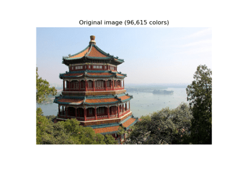

Color Quantization using K-Means

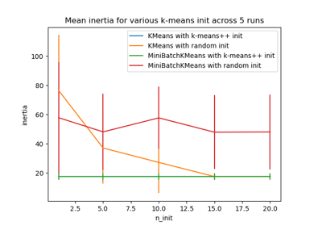

Empirical evaluation of the impact of k-means initialization

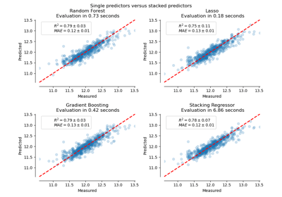

Combine predictors using stacking

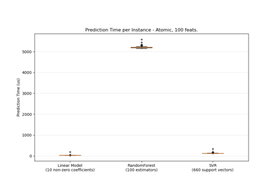

Prediction Latency

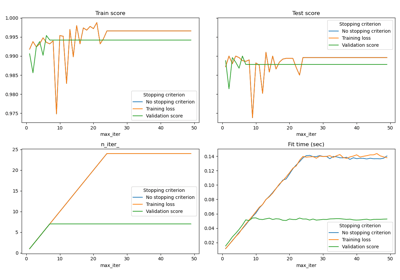

Early stopping of Stochastic Gradient Descent

[figure not shown]

Approximate nearest neighbors in TSNE

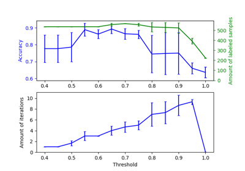

Effect of varying threshold for self-training

© 2007–2022 The scikit-learn developers  
Licensed under the 3-clause BSD License.  
https://scikit-learn.org/1.1/modules/generated/sklearn.utils.shuffle.html